# German Credit

# Analysis

```r
c(bestLassoValue, bestRidgeValue, bestLDAValue, bestLogisitcValue)
```

```
## [1] 217 223 391 230
```

Let’s take a look at the relative successes of each model according to the provided scoring matrix.

And, as requested, we have ROC curves for each model.

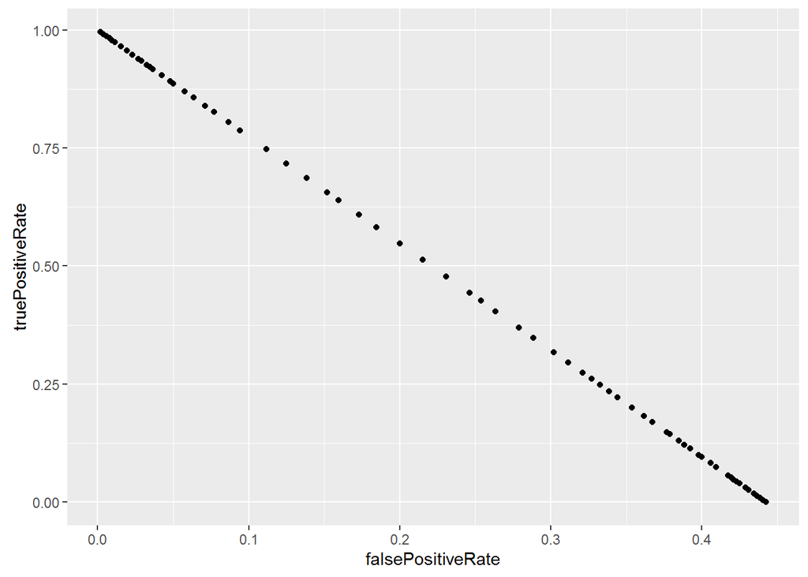

```r
# use lasso
ratesLasso.df <- data.frame(ratesMatrixLasso)
colnames(ratesLasso.df) <- c("p", "truePositiveRate", "falsePositiveRate")
ggplot(ratesLasso.df, aes(falsePositiveRate, truePositiveRate)) + geom_point()
```

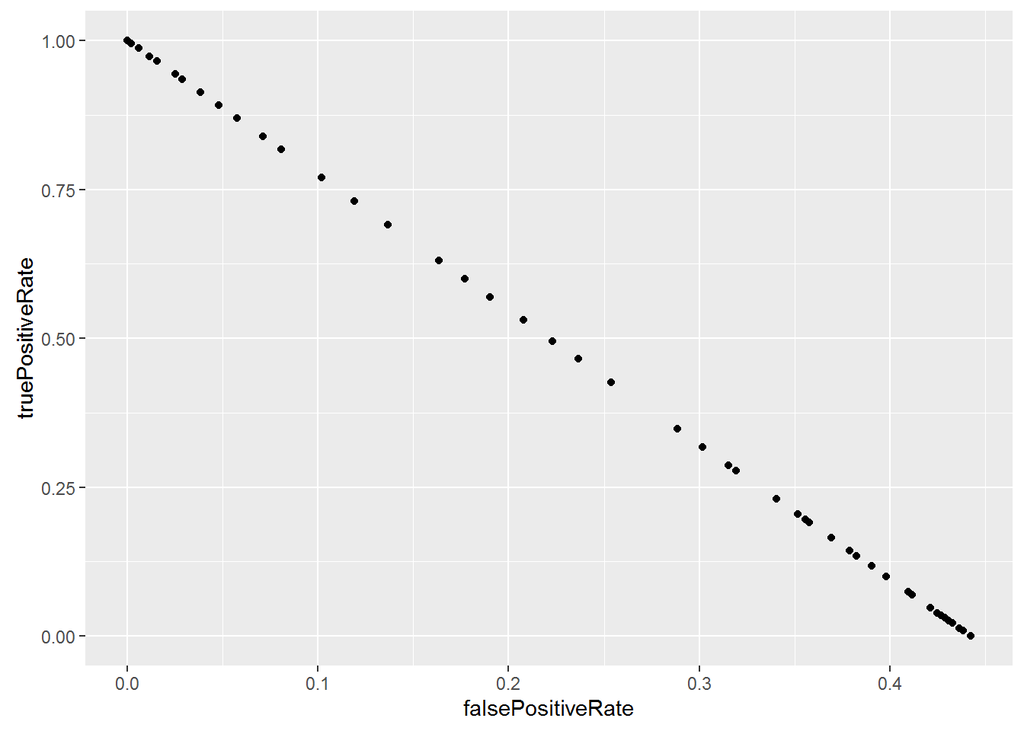

```r
# use Ridge
ratesRidge.df <- data.frame(ratesMatrixRidge)
colnames(ratesRidge.df) <- c("p", "truePositiveRate", "falsePositiveRate")
ggplot(ratesRidge.df, aes(falsePositiveRate, truePositiveRate)) + geom_point()
```

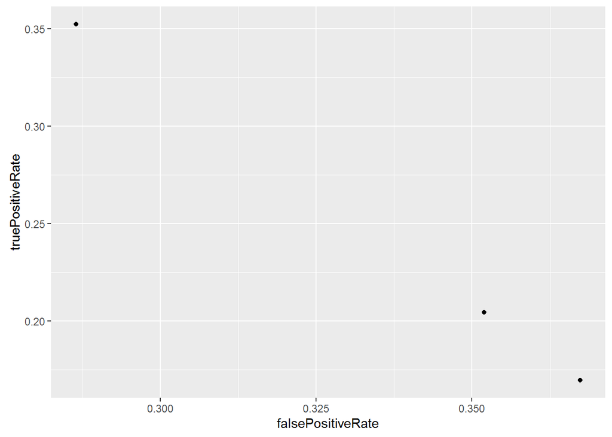

```r
# use LDA
ratesLDA.df <- data.frame(ratesMatrixLDA)
colnames(ratesLDA.df) <- c("p", "truePositiveRate", "falsePositiveRate")
ggplot(ratesLDA.df, aes(falsePositiveRate, truePositiveRate)) + geom_point()
```

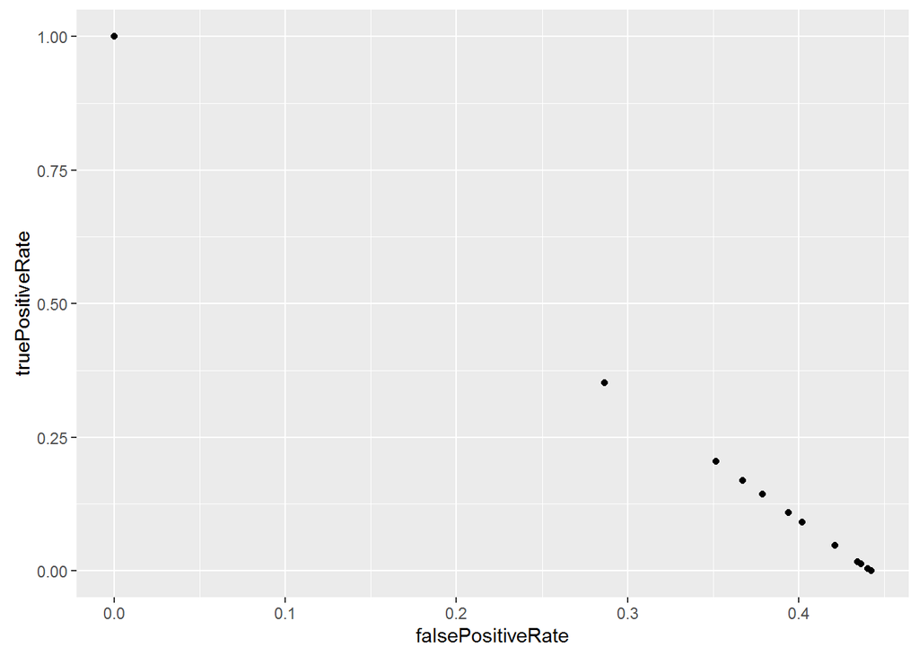

```r
# use Logistic
ratesLogistic.df <- data.frame(ratesMatrixLogistic)
colnames(ratesLogistic.df) <- c("p", "truePositiveRate", "falsePositiveRate")
ggplot(ratesLogistic.df, aes(falsePositiveRate, truePositiveRate)) + geom_point()
```

They don’t look great.

## Conclusion

In this situation, I would use the lasso or ridge models for prediction. There are so many predictors in the numeric set that we would have to reduce to the important ones for anything else to be effective, which necessitates using the lasso or ridge techniques anyway.